# Sketching-based evaluation of spatial transcriptomics subsampling methods

## Spatially varible gene analysis w/ Moran's I

Divergent performance emerged when evaluating preservation of spatial gene expression patterns: leverage score variants excelled, recovering the ranking and values of the top 25 spatially variable genes (SVGs). SVD-based leverage scoring captured genes whose spatial organization is coupled with transcriptomic informativeness, producing minimal error relative to the full dataset. Geometric methods significantly underperformed: both geoSketch and scSampler using transcriptomic or coordinate inputs showed substantially elevated error for spatially variable genes, particularly for the most highly spatially organized features. This suggests that uniform manifold coverage may inadvertently under-represent cells in spatially coherent neighborhoods, a critical oversight for identifying region-specific gene expression patterns (See Fig 4). Note that for the squared error heatmap, the darker colors represent better concordance to the full dataset.

```python
# store results here
moran_results = {}

# full dataset first
sq.gr.spatial_neighbors(adata)
sq.gr.spatial_autocorr(
    adata,
    mode="moran",
    n_perms=100,
    n_jobs=1,
)

# Moran's I results are stored in .uns
moran_results["full"] = adata.uns["moranI"].copy()

# now each sketch
for name, ad in sketches:
    print(f"Processing {name}...")

    sq.gr.spatial_neighbors(ad)
    sq.gr.spatial_autocorr(
        ad,
        mode="moran",
        n_perms=100,
        n_jobs=1,
    )

    moran_results[name] = ad.uns["moranI"].copy()
```

```
Processing leverage...
```

```
Processing leverage_svd...
```

```
Processing leverage_svd_smoothed...
```

```
Processing geo_transcriptomic...
```

```
Processing geo_coordinate...
```

```
Processing geo_smoothed...
```

```
Processing scsampler_transcriptomic...
```

```
Processing scsampler_coordinate...
```

```
Processing scsampler_smoothed...
```

```
Processing uniform...
```

```python
#combine the results into a single dataframe for plotting:
combined = []
for method, df in moran_results.items():
    tmp = df.copy()
    tmp = tmp.reset_index().rename(columns={"index": "feature"})
    tmp["method"] = method
    combined.append(tmp)

gene_moran_df = pd.concat(combined, ignore_index=True)
```

```python
#define an ordering for plotting
method_order = [
    'full',
    'leverage_svd_smoothed',
    'scsampler_smoothed',
    'geo_smoothed',
    'leverage',
    'leverage_svd',
    'scsampler_transcriptomic',
    'geo_transcriptomic',
    'scsampler_coordinate',
    'geo_coordinate',
    'uniform'
]
```

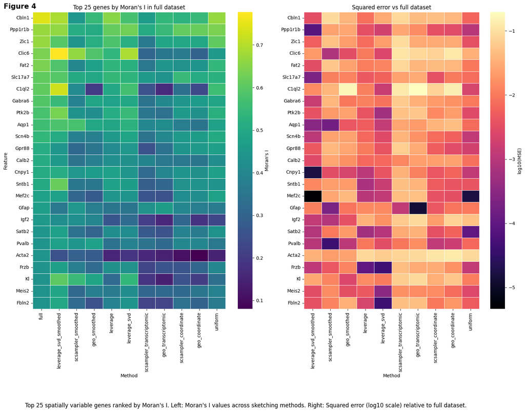

```python
moran_mat, mse_mat = plot_moran_and_mse_heatmaps(
    gene_moran_df,
    feature_col="feature",
    value_col="I",
    method_col="method",
    full_method="full",
    method_order=method_order,
    n_features=25,
    figsize=(16, 10),
    cmap_left="viridis",
    cmap_right="magma",
    log_mse=True,
    fig_label="Figure 4",
    fig_caption="Top 25 spatially variable genes ranked by Moran's I. "
                "Left: Moran's I values across sketching methods. "
                "Right: Squared error (log10 scale) relative to full dataset. "
                ,
    save=None,
)
```

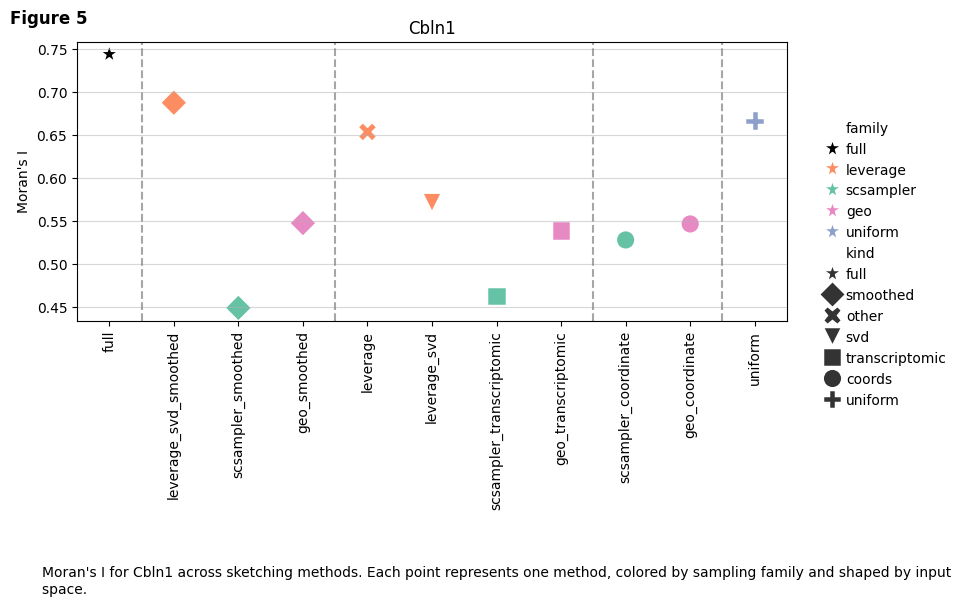

```python
plot_feature_moran_scatter(
    gene_moran_df,
    feature="Cbln1",
    order=method_order,
    figsize=(8, 4),
    point_size=180,
    fig_label="Figure 5",
    fig_caption="Moran's I for Cbln1 across sketching methods. "
                "Each point represents one method, colored by sampling family and shaped by input space. "
                ,
    save=None,
)
```

[output not shown]

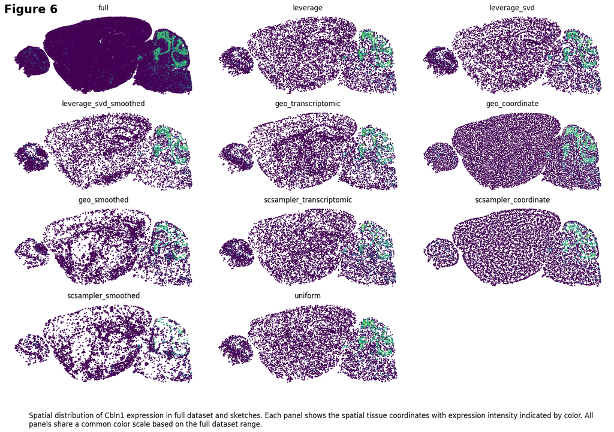

```python
fig = plot_spatial_feature_panels(
    adata,
    sketches,
    feature="Cbln1",
    ncols=3,
    figsize_per_panel=(5, 2),
    size=2.5,
    fig_label="Figure 6",
    fig_caption="Spatial distribution of Cbln1 expression in full dataset and sketches. "
                "Each panel shows the spatial tissue coordinates with expression intensity indicated by color. "
                "All panels share a common color scale based on the full dataset range.",
    save=None,
)
```

## Bivariate metrics (Cell-Cell interactions) using LIANA-py

In this section, we use [LIANA+](https://liana-py.readthedocs.io/) to evaluate how well each sketch preserves **spatially-informed ligand–receptor interaction structure** relative to the full dataset. LIANA computes local bivariate scores for candidate ligand–receptor pairs using the spatial graph, and summarizes these patterns globally for each interaction. Here, we focus on the global summaries returned by `li.mt.bivariate`, including the interaction-level **mean** local score and **Moran’s I** of the local interaction pattern.

We apply the same LIANA workflow to the full dataset and to each sketch, then compare methods by:

- plotting the top interactions ranked in the full dataset,
- measuring error relative to the full dataset,
- and visualizing the spatial distribution of selected interaction scores.

For full details on available metrics, parameters, and outputs, please refer to the LIANA+ API and documentation: [https://liana-py.readthedocs.io/en/latest/notebooks/bivariate.html)

### Result summary:

Cell-cell interaction (CCI) analysis revealed similar stratification patterns to gene spatial autocorrelation. Leverage-based methods preserved global interaction structure, with moderate error for the top 25 interactions ranked by mean local score. Smoothed variants again showed slight advantages, suggesting that spatial coherence provides additional signal beyond transcriptomic informativeness. geosketch and scSampler-based sketches, particularly those computed on the transcriptomic latent space, exhibited higher error for interaction detection compared to leverage-based approaches for top-ranked interactions. This performance gap directly reflects their difficulty recovering spatially organized cell populations; cells expressing ligands and receptors often cluster in tissue-specific domains (Fig 7).

When evaluating Moran's I values of local interaction scores (a measure of the spatially clustered of a given interaction), the performance was less distinguishable and somewhat interaction specific. We choose to highlight two interactions to show this lack of pattern (Fig 8).

#### Example interactions:

```python
def scale_spatial_once(ad, scale_factor=100, key="spatial", flag_key="_spatial_scaled_for_liana"):
    if flag_key not in ad.uns:
        ad.obsm[key] = ad.obsm[key] * scale_factor
        ad.uns[flag_key] = scale_factor
```

```python
# scale coords once
scale_spatial_once(adata, scale_factor=100)

for name, ad in sketches:
    scale_spatial_once(ad, scale_factor=100)

# run LIANA
liana_results = {}
liana_var_results = {}

print("Processing full...")
lr_full = run_liana_bivariate(adata)
liana_results["full"] = lr_full
liana_var_results["full"] = lr_full.var.copy()

for name, ad in sketches:
    print(f"Processing {name}...")
    lr = run_liana_bivariate(ad)
    liana_results[name] = lr
    liana_var_results[name] = lr.var.copy()
```

```
Processing full...
```

```
2026-04-02 12:19:19 | [INFO] Using `.X`!
2026-04-02 12:19:19 | [INFO] Converting to sparse csr matrix!
2026-04-02 12:19:20 | [INFO] Using resource `mouseconsensus`.
2026-04-02 12:19:54 | [INFO] Using `.X`!
2026-04-02 12:19:54 | [INFO] Converting to sparse csr matrix!
```

```
Processing leverage...
```

```
Processing leverage_svd...
```

```
2026-04-02 12:20:04 | [INFO] Using `.X`!
2026-04-02 12:20:04 | [INFO] Converting to sparse csr matrix!
2026-04-02 12:20:04 | [INFO] Using resource `mouseconsensus`.
```

```
Processing leverage_svd_smoothed...
```

```
2026-04-02 12:20:09 | [INFO] Using `.X`!
2026-04-02 12:20:09 | [INFO] Converting to sparse csr matrix!
2026-04-02 12:20:09 | [INFO] Using resource `mouseconsensus`.
```

```
Processing geo_transcriptomic...
```

```
2026-04-02 12:20:13 | [INFO] Using `.X`!
2026-04-02 12:20:13 | [INFO] Converting to sparse csr matrix!
2026-04-02 12:20:13 | [INFO] Using resource `mouseconsensus`.
```

```
Processing geo_coordinate...
```

```
2026-04-02 12:20:18 | [INFO] Using `.X`!
2026-04-02 12:20:18 | [INFO] Converting to sparse csr matrix!
2026-04-02 12:20:18 | [INFO] Using resource `mouseconsensus`.
```

```
Processing geo_smoothed...
```

```
2026-04-02 12:20:22 | [INFO] Using `.X`!
2026-04-02 12:20:22 | [INFO] Converting to sparse csr matrix!
2026-04-02 12:20:22 | [INFO] Using resource `mouseconsensus`.
```

```
Processing scsampler_transcriptomic...
```

```
2026-04-02 12:20:26 | [INFO] Using `.X`!
2026-04-02 12:20:26 | [INFO] Converting to sparse csr matrix!
2026-04-02 12:20:26 | [INFO] Using resource `mouseconsensus`.
```

```
Processing scsampler_coordinate...
```

```
2026-04-02 12:20:31 | [INFO] Using `.X`!
2026-04-02 12:20:31 | [INFO] Converting to sparse csr matrix!
2026-04-02 12:20:31 | [INFO] Using resource `mouseconsensus`.
```

```
Processing scsampler_smoothed...
```

```
2026-04-02 12:20:36 | [INFO] Using `.X`!
2026-04-02 12:20:36 | [INFO] Converting to sparse csr matrix!
2026-04-02 12:20:36 | [INFO] Using resource `mouseconsensus`.
```

```
Processing uniform...
```

```python
combined_lr = []
for method, df in liana_var_results.items():
    tmp = df.copy()
    tmp = tmp.reset_index().rename(columns={"index": "feature"})
    tmp["method"] = method
    combined_lr.append(tmp)

lr_summary_df = pd.concat(combined_lr, ignore_index=True)
```

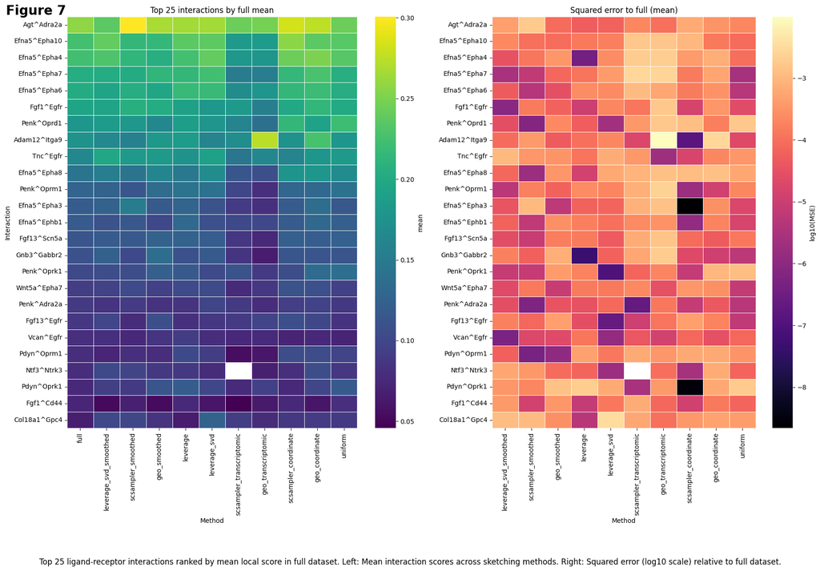

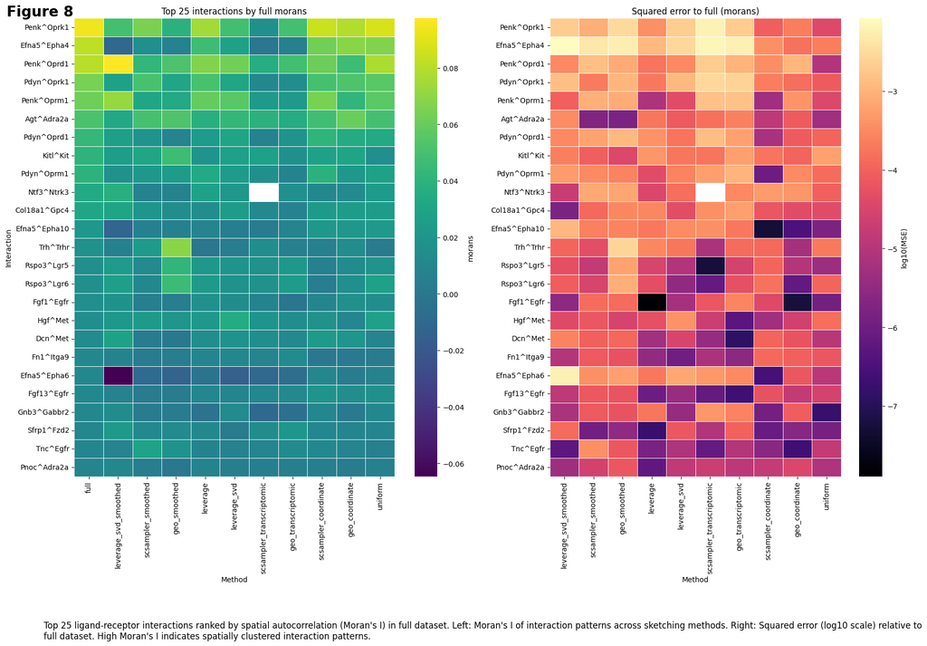

```python
# Figure 7: Mean interaction score
plot_feature_value_and_mse_heatmaps(
    lr_summary_df,
    feature_col="interaction",
    value_col="mean",
    method_col="method",
    full_method="full",
    method_order=method_order,
    n_features=25,
    figsize=(18, 10),
    cmap_left="viridis",
    cmap_right="magma",
    log_mse=True,
    fig_label="Figure 7",
    fig_caption="Top 25 ligand-receptor interactions ranked by mean local score in full dataset. "
                "Left: Mean interaction scores across sketching methods. "
                "Right: Squared error (log10 scale) relative to full dataset. "
                ,
    save=None,
)

# Figure 8: Moran's I of interaction pattern
plot_feature_value_and_mse_heatmaps(
    lr_summary_df,
    feature_col="interaction",
    value_col="morans",
    method_col="method",
    full_method="full",
    method_order=method_order,
    n_features=25,
    figsize=(18, 10),
    cmap_left="viridis",
    cmap_right="magma",
    log_mse=True,
    fig_label="Figure 8",
    fig_caption="Top 25 ligand-receptor interactions ranked by spatial autocorrelation (Moran's I) in full dataset. "
                "Left: Moran's I of interaction patterns across sketching methods. "
                "Right: Squared error (log10 scale) relative to full dataset. "
                "High Moran's I indicates spatially clustered interaction patterns.",
    save=None,
)
```

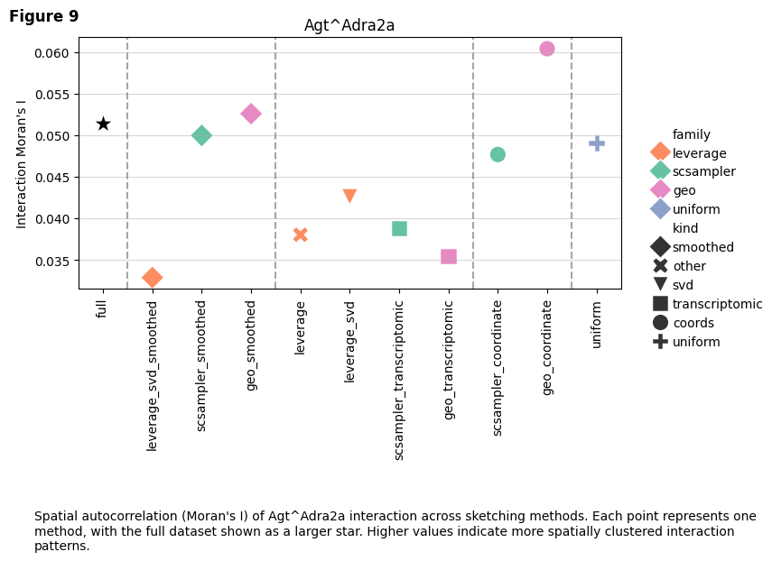

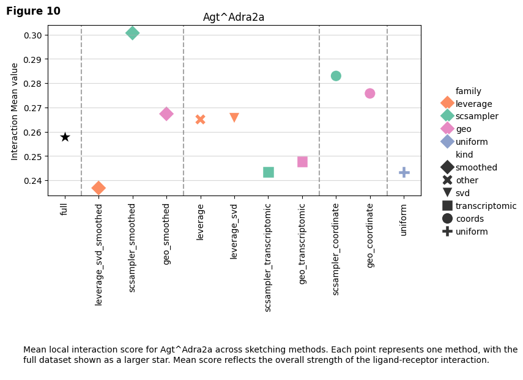

```python
# Figure 9: Moran's I for Agt^Adra2a
plot_feature_scatter(
    lr_summary_df,
    feature="Agt^Adra2a",
    feature_col='interaction',
    value_col="morans",
    order=method_order,
    ylabel="Interaction Moran's I",
    fig_label="Figure 9",
    fig_caption="Spatial autocorrelation (Moran's I) of Agt^Adra2a interaction across sketching methods. "
                "Each point represents one method, with the full dataset shown as a larger star. "
                "Higher values indicate more spatially clustered interaction patterns.",
    save=None,
)

# Figure 10: Mean score for Agt^Adra2a
plot_feature_scatter(
    lr_summary_df,
    feature="Agt^Adra2a",
    feature_col='interaction',
    value_col="mean",
    order=method_order,
    ylabel="Interaction Mean value",
    fig_label="Figure 10",
    fig_caption="Mean local interaction score for Agt^Adra2a across sketching methods. "
                "Each point represents one method, with the full dataset shown as a larger star. "
                "Mean score reflects the overall strength of the ligand-receptor interaction.",
    save=None,
)
```

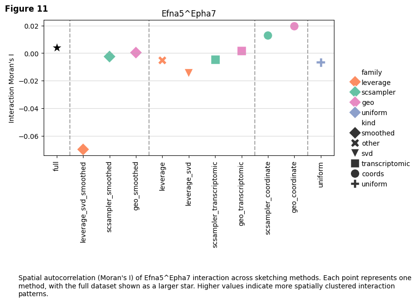

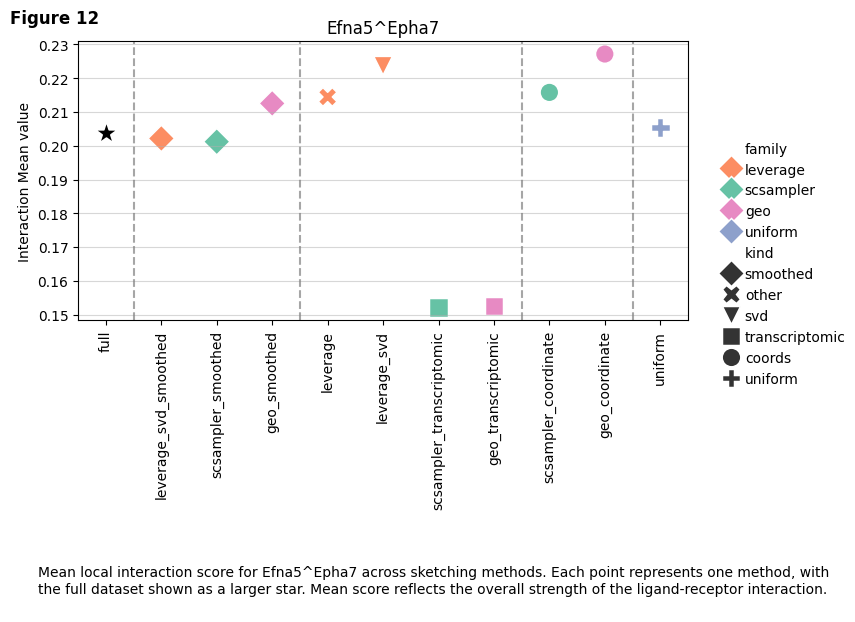

```python
# Figure 11: Moran's I for Efna5^Epha7
plot_feature_scatter(
    lr_summary_df,
    feature="Efna5^Epha7",
    feature_col='interaction',
    value_col="morans",
    order=method_order,
    ylabel="Interaction Moran's I",
    fig_label="Figure 11",
    fig_caption="Spatial autocorrelation (Moran's I) of Efna5^Epha7 interaction across sketching methods. "
                "Each point represents one method, with the full dataset shown as a larger star. "
                "Higher values indicate more spatially clustered interaction patterns.",
    save=None,
)

# Figure 12: Mean score for Efna5^Epha7
plot_feature_scatter(
    lr_summary_df,
    feature="Efna5^Epha7",
    feature_col='interaction',
    value_col="mean",
    order=method_order,
    ylabel="Interaction Mean value",
    fig_label="Figure 12",
    fig_caption="Mean local interaction score for Efna5^Epha7 across sketching methods. "
                "Each point represents one method, with the full dataset shown as a larger star. "
                "Mean score reflects the overall strength of the ligand-receptor interaction.",
    save=None,
)
```